# FordGoBike Data Exploration

## Introduction

> This document explores a dataset containing information about individual rides made in a bike-sharing system covering the greater San Francisco Bay area

## Preliminary Wrangling

```python
# import all packages and set plots to be embedded inline
import numpy as np
import pandas as pd
import matplotlib.pyplot as plt
import seaborn as sb

%matplotlib inline
```

> Loading Data Set

```python
bike_data = pd.read_csv('201902-fordgobike-tripdata.csv')
bike_data.head()
```

|  | duration_sec | start_time | end_time | start_station_id | start_station_name | start_station_latitude | start_station_longitude | end_station_id | end_station_name | end_station_latitude | end_station_longitude | bike_id | user_type | member_birth_year | member_gender | bike_share_for_all_trip |
| --- | --- | --- | --- | --- | --- | --- | --- | --- | --- | --- | --- | --- | --- | --- | --- | --- |
| 0 | 52185 | 2019-02-28 17:32:10.1450 | 2019-03-01 08:01:55.9750 | 21.0 | Montgomery St BART Station (Market St at 2nd St) | 37.789625 | -122.400811 | 13.0 | Commercial St at Montgomery St | 37.794231 | -122.402923 | 4902 | Customer | 1984.0 | Male | No |
| 1 | 42521 | 2019-02-28 18:53:21.7890 | 2019-03-01 06:42:03.0560 | 23.0 | The Embarcadero at Steuart St | 37.791464 | -122.391034 | 81.0 | Berry St at 4th St | 37.775880 | -122.393170 | 2535 | Customer | NaN | NaN | No |
| 2 | 61854 | 2019-02-28 12:13:13.2180 | 2019-03-01 05:24:08.1460 | 86.0 | Market St at Dolores St | 37.769305 | -122.426826 | 3.0 | Powell St BART Station (Market St at 4th St) | 37.786375 | -122.404904 | 5905 | Customer | 1972.0 | Male | No |
| 3 | 36490 | 2019-02-28 17:54:26.0100 | 2019-03-01 04:02:36.8420 | 375.0 | Grove St at Masonic Ave | 37.774836 | -122.446546 | 70.0 | Central Ave at Fell St | 37.773311 | -122.444293 | 6638 | Subscriber | 1989.0 | Other | No |
| 4 | 1585 | 2019-02-28 23:54:18.5490 | 2019-03-01 00:20:44.0740 | 7.0 | Frank H Ogawa Plaza | 37.804562 | -122.271738 | 222.0 | 10th Ave at E 15th St | 37.792714 | -122.248780 | 4898 | Subscriber | 1974.0 | Male | Yes |

## Data Wrangling

> **Acessing The Data**

```python
bike_data.info()
```

```
<class 'pandas.core.frame.DataFrame'>
RangeIndex: 183412 entries, 0 to 183411
Data columns (total 16 columns):
duration_sec               183412 non-null int64
start_time                 183412 non-null object
end_time                   183412 non-null object
start_station_id           183215 non-null float64
start_station_name         183215 non-null object
start_station_latitude     183412 non-null float64
start_station_longitude    183412 non-null float64
end_station_id             183215 non-null float64
end_station_name           183215 non-null object
end_station_latitude       183412 non-null float64
end_station_longitude      183412 non-null float64
bike_id                    183412 non-null int64
user_type                  183412 non-null object
member_birth_year          175147 non-null float64
member_gender              175147 non-null object
bike_share_for_all_trip    183412 non-null object
dtypes: float64(7), int64(2), object(7)
memory usage: 22.4+ MB
```

```python
#Looking at the data structure and properties

def basic_stat(dataframe):

    data_shape= dataframe.shape

    other_info = dataframe.describe()

    list_of_columns = list(dataframe.columns.values)

    null_data = dataframe.isnull().any().any()


    return data_shape, other_info, list_of_columns, null_data

data_summary = basic_stat(bike_data)

print(f'The shape of the 201902-fordgobike-tripdata.csv dataset is {data_summary[0]}')
print(f'The dataset has the following column names: {data_summary[2]}')
print(f'Are they any null values in the dataset? : {data_summary[3]}')
```

```
The shape of the 201902-fordgobike-tripdata.csv dataset is (183412, 16)
The dataset has the following column names: ['duration_sec', 'start_time', 'end_time', 'start_station_id', 'start_station_name', 'start_station_latitude', 'start_station_longitude', 'end_station_id', 'end_station_name', 'end_station_latitude', 'end_station_longitude', 'bike_id', 'user_type', 'member…
Are they any null values in the dataset? : True
```

```python
#Checkking the total number of columns with null values
bike_data.isnull().any().sum()
```

```
6
```

```python
# Checking null value for each column
bike_data.isna().sum()
```

```
duration_sec                  0
start_time                    0
end_time                      0
start_station_id            197
start_station_name          197
start_station_latitude        0
start_station_longitude       0
end_station_id              197
end_station_name            197
end_station_latitude          0
end_station_longitude         0
bike_id                       0
user_type                     0
member_birth_year          8265
member_gender              8265
bike_share_for_all_trip       0
dtype: int64
```

```python
#Drop null values
bike_data.dropna(inplace=True)
```

```python
# Checking null value for each column
bike_data.isna().sum()
```

```
duration_sec               0
start_time                 0
end_time                   0
start_station_id           0
start_station_name         0
start_station_latitude     0
start_station_longitude    0
end_station_id             0
end_station_name           0
end_station_latitude       0
end_station_longitude      0
bike_id                    0
user_type                  0
member_birth_year          0
member_gender              0
bike_share_for_all_trip    0
dtype: int64
```

```python
#Descibe the data set
data_summary[1]
```

|  | duration_sec | start_station_id | start_station_latitude | start_station_longitude | end_station_id | end_station_latitude | end_station_longitude | bike_id | member_birth_year |
| --- | --- | --- | --- | --- | --- | --- | --- | --- | --- |
| count | 183412.000000 | 183215.000000 | 183412.000000 | 183412.000000 | 183215.000000 | 183412.000000 | 183412.000000 | 183412.000000 | 175147.000000 |
| mean | 726.078435 | 138.590427 | 37.771223 | -122.352664 | 136.249123 | 37.771427 | -122.352250 | 4472.906375 | 1984.806437 |
| std | 1794.389780 | 111.778864 | 0.099581 | 0.117097 | 111.515131 | 0.099490 | 0.116673 | 1664.383394 | 10.116689 |
| min | 61.000000 | 3.000000 | 37.317298 | -122.453704 | 3.000000 | 37.317298 | -122.453704 | 11.000000 | 1878.000000 |
| 25% | 325.000000 | 47.000000 | 37.770083 | -122.412408 | 44.000000 | 37.770407 | -122.411726 | 3777.000000 | 1980.000000 |
| 50% | 514.000000 | 104.000000 | 37.780760 | -122.398285 | 100.000000 | 37.781010 | -122.398279 | 4958.000000 | 1987.000000 |
| 75% | 796.000000 | 239.000000 | 37.797280 | -122.286533 | 235.000000 | 37.797320 | -122.288045 | 5502.000000 | 1992.000000 |
| max | 85444.000000 | 398.000000 | 37.880222 | -121.874119 | 398.000000 | 37.880222 | -121.874119 | 6645.000000 | 2001.000000 |

```python
#Checking for duplicates in the data set
bike_data.duplicated().sum()
```

```
0
```

```python
#Making a copy before cleaning
bike_data_clean = bike_data.copy()
```

### Structure of the dataset

- The dataset has a total of 16 features and 183,412 trips
- six of the columns contain null values
- There's no duplictaes in the data set
- The data set mainly has three data types, object, float and int
- The `start_time` and `end_time` features of this data types are objects, they need to be coverted to datetime data type

### Main feature(s) of interest in the dataset

- the main features we will look at in this data set are:
  - `duration_sec`
  - `user_type`
  - `start_time`

### Features in the dataset that will help support the investigation into the feature(s) of interest

- Features like `end_time`, `start_station_name`, `end_station_name` will help us to determine the time and place where trips are taken.
- The `user_type` and `membe_gender` features will also help us to determine the type of users and genderof the people who uses the bikes often.

> **Cleaning The Data**

### Define

- Converting the `start_time` and `end_time` features of this data types from objects to datetime data type

### Code

```python
bike_data_clean['start_time'] = pd.to_datetime(bike_data_clean['start_time'])
bike_data_clean['end_time'] = pd.to_datetime(bike_data_clean['end_time'])
```

### Test

```python
#checking the data types
bike_data_clean.info()
```

```
<class 'pandas.core.frame.DataFrame'>
Int64Index: 174952 entries, 0 to 183411
Data columns (total 16 columns):
duration_sec               174952 non-null int64
start_time                 174952 non-null datetime64[ns]
end_time                   174952 non-null datetime64[ns]
start_station_id           174952 non-null float64
start_station_name         174952 non-null object
start_station_latitude     174952 non-null float64
start_station_longitude    174952 non-null float64
end_station_id             174952 non-null float64
end_station_name           174952 non-null object
end_station_latitude       174952 non-null float64
end_station_longitude      174952 non-null float64
bike_id                    174952 non-null int64
user_type                  174952 non-null object
member_birth_year          174952 non-null float64
member_gender              174952 non-null object
bike_share_for_all_trip    174952 non-null object
dtypes: datetime64[ns](2), float64(7), int64(2), object(5)
memory usage: 22.7+ MB
```

# Exploratory Analysis

## Univariate Exploration

### Distribution of trips between user types

```python
bike_data_clean.user_type.unique()
```

```
array(['Customer', 'Subscriber'], dtype=object)
```

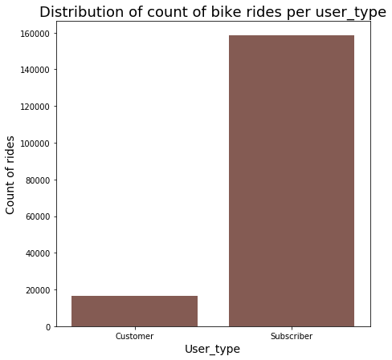

```python
default_color = sb.color_palette()[5]

# same distribution in countplot format
plt.figure(figsize=(7,7))


sb.countplot(data=bike_data_clean, x='user_type', color=default_color)
plt.xlabel('User_type', fontsize=14)
plt.ylabel('Count of rides', fontsize=14)
plt.title('Distribution of count of bike rides per user_type', fontsize=18);
```

- There are only two types of bike users put into two categgories:-
  - Customer
  - Subscriber
- Subscribers were the onces who took more rides

### Distribution of rides based on user's Age

```python
#Create Age
bike_data_clean['age'] = bike_data_clean['member_birth_year'].apply(lambda x: 2022 - x)
```

```python
# creating age_group column
a_bins = [21,35,60,144]
grp = ['young', 'middle_age', 'senior']
bike_data_clean['age_group'] = pd.cut(bike_data_clean['age'], bins=a_bins, labels=grp, include_lowest=True)
```

```python
bike_data_clean.age.describe()
```

```
count    174952.000000
mean         37.196865
std          10.118731
min          21.000000
25%          30.000000
50%          35.000000
75%          42.000000
max         144.000000
Name: age, dtype: float64
```

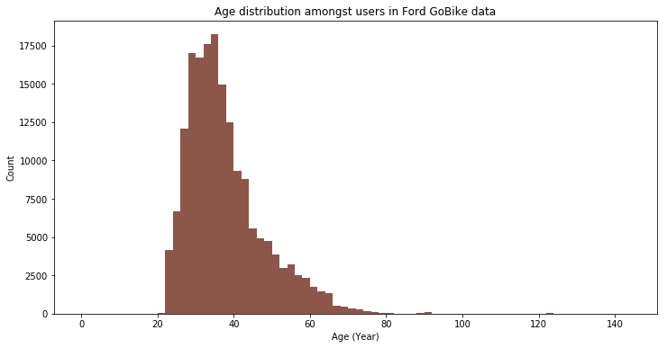

```python
plt.figure(figsize=(12,6))

bins = np.arange(0, bike_data_clean['age'].max()+2, 2)
plt.hist(data=bike_data_clean, x='age', bins=bins, color=default_color)
plt.xlabel('Age (Year)')
plt.ylabel('Count')
plt.title('Age distribution amongst users in Ford GoBike data');
```

- The distribution among the ages of users is right skewed with a few outliers

### Duration Distribution

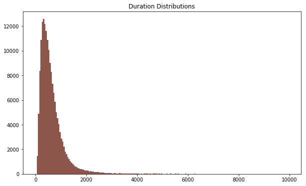

```python
plt.figure(figsize=(10,6))
bins = np.arange(0, 10000, 50)

plt.hist(data=bike_data_clean, x='duration_sec', bins=bins, color=default_color)
plt.title('Duration Distributions');
```

- The duration taken is right skewed

### Exploration of Datetime

```python
#Extracting the months
bike_data_clean['month'] = bike_data_clean['start_time'].dt.month_name()
#Extracting the days
bike_data_clean['start_day'] = bike_data_clean['start_time'].dt.day_name()
#Extracting the time of day
bike_data_clean['hour'] = bike_data_clean['start_time'].dt.hour
#Extracting the dates
bike_data_clean['date'] = bike_data_clean['start_time'].dt.date
```

```python
bike_data_clean['month'].value_counts()
```

```
February    174952
Name: month, dtype: int64
```

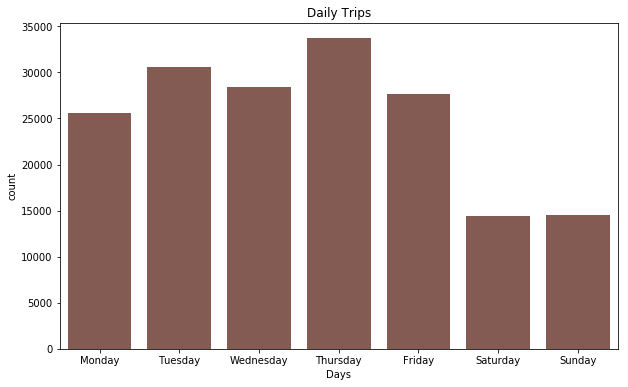

```python
#Bike Trip frequency distribution by day
plt.figure(figsize=(10,6))

day_name = ["Monday","Tuesday","Wednesday","Thursday","Friday","Saturday","Sunday"]

plt.title('Daily Trips')
sb.countplot(data = bike_data_clean, x = 'start_day', order=day_name, color = default_color)
plt.xlabel('Days');
```

- Most trips were taken between Monday and Friday with Thursday having the highest number of trips taken.
- Sunday and Sartuday recorded a low number of trips

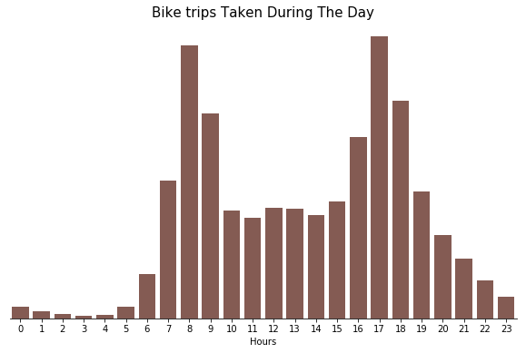

```python
#Based on the hour of day
hour_order = np.arange(0,24)

plt.figure(figsize=(10,6))
plt.title('Bike trips Taken During The Day', fontsize=15)
ax = sb.countplot(data=bike_data_clean, x='hour', order=hour_order, color=default_color)

ax.spines['top'].set_visible(False)
ax.spines['right'].set_visible(False)
ax.spines['left'].set_visible(False)
plt.yticks([])
plt.ylabel('')
plt.xlabel('Hours');
```

- The ditribution above shown by the frequency of bike trips during the day is bimodal.
- There is peak bike rides between 8 and 9 in the morning and between 5 and 6 in the evening

### Distribution based on Gender

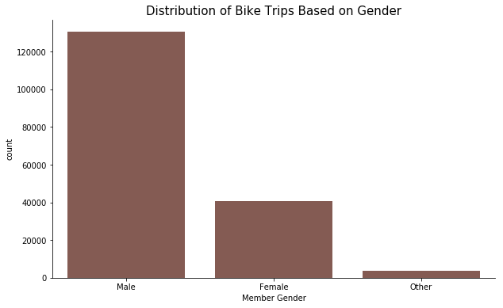

```python
#Distribution of Bike Trips based on The Member_gender
plt.figure(figsize=(10,6))
plt.title('Distribution of Bike Trips Based on Gender', fontsize=15)
ax = sb.countplot(data = bike_data_clean, x = 'member_gender', color = default_color, order=bike_data_clean.member_gender.value_counts().index)
ax.spines['top'].set_visible(False)
ax.spines['right'].set_visible(False)
ax.spines['left'].set_visible(True)
plt.xlabel('Member Gender');
```

- Most of the Bike Trips were taken by Males

### Start Stations

```python
bike_data_clean.start_station_name.nunique()
```

```
329
```

```python
bike_data_clean.start_station_name.value_counts()
```

```
Market St at 10th St                                               3649
San Francisco Caltrain Station 2  (Townsend St at 4th St)          3408
Berry St at 4th St                                                 2952
Montgomery St BART Station (Market St at 2nd St)                   2711
Powell St BART Station (Market St at 4th St)                       2620
San Francisco Caltrain (Townsend St at 4th St)                     2577
San Francisco Ferry Building (Harry Bridges Plaza)                 2541
Howard St at Beale St                                              2216
Steuart St at Market St                                            2191
Powell St BART Station (Market St at 5th St)                       2144
The Embarcadero at Sansome St                                      1975
Bancroft Way at Telegraph Ave                                      1761
Bancroft Way at College Ave                                        1712
2nd St at Townsend St                                              1702
Beale St at Harrison St                                            1678
3rd St at Townsend St                                              1675
Embarcadero BART Station (Beale St at Market St)                   1646
4th St at Mission Bay Blvd S                                       1496
Townsend St at 7th St                                              1479
Civic Center/UN Plaza BART Station (Market St at McAllister St)    1476
The Embarcadero at Steuart St                                      1420
Downtown Berkeley BART                                             1322
Post St at Kearny St                                               1311
4th St at 16th St                                                  1274
Howard St at 8th St                                                1257
19th Street BART Station                                           1231
Esprit Park                                                        1226
Rhode Island St at 17th St                                         1224
Hearst Ave at Euclid Ave                                           1176
8th St at Brannan St                                               1154
                                                                   ...
45th St at MLK Jr Way                                                54
27th St at MLK Jr Way                                                54
San Antonio Park                                                     53
Mendell St at Fairfax Ave                                            53
Locust St at Grant St                                                49
Williams Ave at 3rd St                                               48
Delmas Ave and San Fernando St                                       47
San Carlos St at Market St                                           37
Lane St at Revere Ave                                                36
Foothill Blvd at Harrington Ave                                      35
Almaden Blvd at Balbach St                                           32
Mission St at 1st St                                                 32
George St at 1st St                                                  31
Oak St at 1st St                                                     30
Empire St at 7th St                                                  28
SAP Center                                                           27
Williams Ave at Apollo St                                            25
Foothill Blvd at 42nd Ave                                            23
26th Ave at International Blvd                                       19
San Pedro St at Hedding St                                           19
23rd Ave at Foothill Blvd                                            17
Backesto Park (Jackson St at 13th St)                                17
Leavenworth St at Broadway                                           16
Taylor St at 9th St                                                  13
Willow St at Vine St                                                  9
Farnam St at Fruitvale Ave                                            9
Parker Ave at McAllister St                                           7
21st Ave at International Blvd                                        4
Palm St at Willow St                                                  3
16th St Depot                                                         2
Name: start_station_name, Length: 329, dtype: int64
```

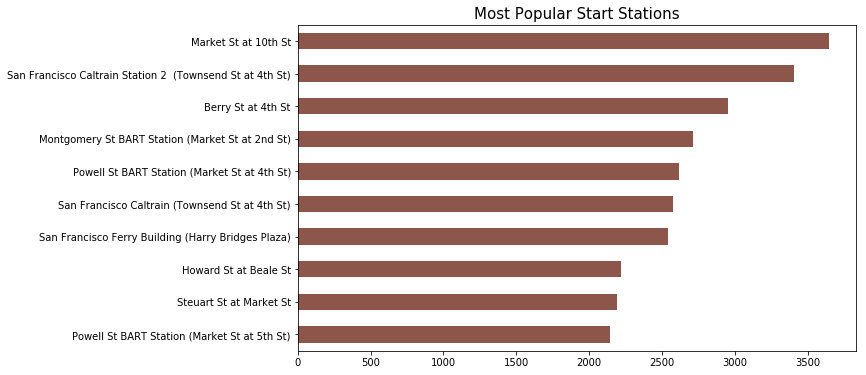

```python
#Most Popular Start stations
plt.figure(figsize=(10,6))
plt.title('Most Popular Start Stations', fontsize=15)
bike_data_clean.start_station_name.value_counts(ascending=True).tail(10).plot.barh(color=default_color);
```

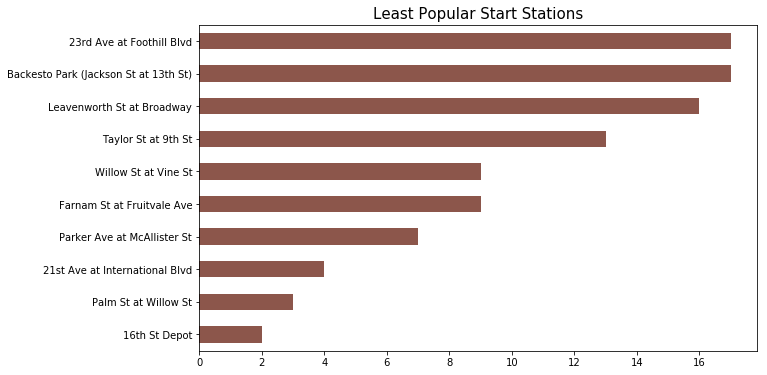

```python
#Least popular start stations
plt.figure(figsize=(10,6))
plt.title('Least Popular Start Stations', fontsize=15)
bike_data_clean.start_station_name.value_counts(ascending=True).head(10).plot.barh(color=default_color);
```

- There are 329 start stations and MarketSt at 10th st has the higest number of trips being taken
- 16th St Depot station has the fewest trips started from that location

### End Stations

```python
bike_data_clean.end_station_name.nunique()
```

```
329
```

```python
bike_data_clean.end_station_name.value_counts()
```

```
San Francisco Caltrain Station 2  (Townsend St at 4th St)          4624
Market St at 10th St                                               3709
Montgomery St BART Station (Market St at 2nd St)                   3461
San Francisco Ferry Building (Harry Bridges Plaza)                 3151
San Francisco Caltrain (Townsend St at 4th St)                     2870
Powell St BART Station (Market St at 4th St)                       2854
Berry St at 4th St                                                 2782
The Embarcadero at Sansome St                                      2341
Steuart St at Market St                                            2264
Powell St BART Station (Market St at 5th St)                       2153
Howard St at Beale St                                              1970
Beale St at Harrison St                                            1780
Bancroft Way at Telegraph Ave                                      1780
Civic Center/UN Plaza BART Station (Market St at McAllister St)    1733
2nd St at Townsend St                                              1667
3rd St at Townsend St                                              1628
Embarcadero BART Station (Beale St at Market St)                   1622
4th St at Mission Bay Blvd S                                       1590
Townsend St at 7th St                                              1440
The Embarcadero at Steuart St                                      1414
19th Street BART Station                                           1392
Post St at Kearny St                                               1366
Downtown Berkeley BART                                             1321
Rhode Island St at 17th St                                         1271
8th St at Brannan St                                               1270
Folsom St at 3rd St                                                1247
Howard St at 8th St                                                1216
Esprit Park                                                        1182
4th St at 16th St                                                  1135
Spear St at Folsom St                                              1116
                                                                   ...
Williams Ave at 3rd St                                               50
Market St at 40th St                                                 48
27th St at MLK Jr Way                                                48
Lane St at Revere Ave                                                46
Locust St at Grant St                                                45
Empire St at 1st St                                                  45
San Carlos St at Market St                                           42
Bestor Art Park                                                      38
SAP Center                                                           37
10th Ave at E 15th St                                                35
Almaden Blvd at Balbach St                                           34
George St at 1st St                                                  33
San Pedro St at Hedding St                                           30
Oak St at 1st St                                                     28
Empire St at 7th St                                                  25
Mission St at 1st St                                                 24
Williams Ave at Apollo St                                            20
Foothill Blvd at 42nd Ave                                            20
26th Ave at International Blvd                                       19
23rd Ave at Foothill Blvd                                            19
Backesto Park (Jackson St at 13th St)                                18
Foothill Blvd at Harrington Ave                                      16
Leavenworth St at Broadway                                           12
Taylor St at 9th St                                                  11
Farnam St at Fruitvale Ave                                           10
Parker Ave at McAllister St                                           9
Palm St at Willow St                                                  7
16th St Depot                                                         6
Willow St at Vine St                                                  5
21st Ave at International Blvd                                        5
Name: end_station_name, Length: 329, dtype: int64
```

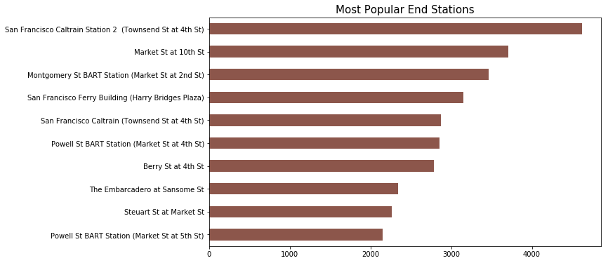

```python
#Most popular end station
plt.figure(figsize=(10,6))
plt.title('Most Popular End Stations', fontsize=15)
bike_data_clean.end_station_name.value_counts(ascending=True).tail(10).plot.barh(color=default_color);
```

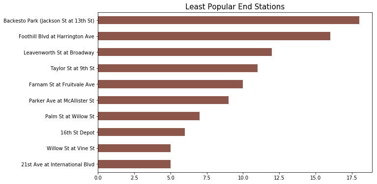

```python
#Least popular end stations
plt.figure(figsize=(10,6))
plt.title('Least Popular End Stations', fontsize=15)
bike_data_clean.end_station_name.value_counts(ascending=True).head(10).plot.barh(color=default_color,);
```

### Discuss the distribution(s) of your variable(s) of interest. Were there any unusual points? Did you need to perform any transformations?

- The distribution of duration taken by all bike users was right skewed
- The distribution of bike rides during the day based on time of day was bimodal

### Of the features you investigated, were there any unusual distributions? Did you perform any operations on the data to tidy, adjust, or change the form of the data? If so, why did you do this?

- I had to add some column to extend fully perform date data analysis, i had to exxtract the day of the week, the hours in the day and the month.

## Bivariate Exploration

### Ride Duration based on member age group

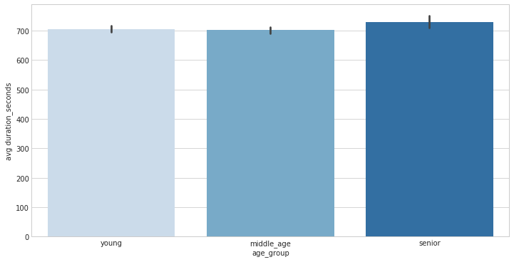

```python
# visualizing age_group and duration
sb.set_style(style='whitegrid')
plt.figure(figsize=(12,6))
sb.barplot(data=bike_data_clean, x='age_group', y='duration_sec', palette='Blues')
plt.ylabel('avg duration_seconds');
```

- Its seems that the average duration rides vary very slighlty by age-roup, with young riders and and middle age having a low while seniors have a higher average, this makes sense since younger riders are generally more energetic, hence are able to ride their bikes faster.

### Ride Duration Based On User Type

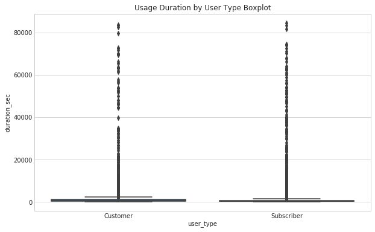

```python
plt.figure(figsize=(10,6))
plt.title('Usage Duration by User Type Boxplot')
sb.boxplot(data=bike_data_clean, x='user_type', y='duration_sec');
```

### Comparison of rides taken by member_gender at various times of the day

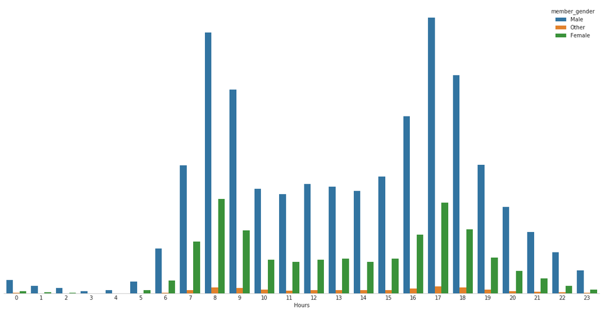

```python
#plot chart

plt.figure(figsize=(20,10))
plt.title('')
ax = sb.countplot(data = bike_data_clean, x = 'hour', hue = 'member_gender')

ax.spines['top'].set_visible(False)
ax.spines['right'].set_visible(False)
ax.spines['left'].set_visible(False)
plt.yticks([])
plt.ylabel('')
plt.xlabel('Hours');
plt.xticks();
```

- During early mornings and late at night most of the Bike riders are male

### Bike usage by User_type each day

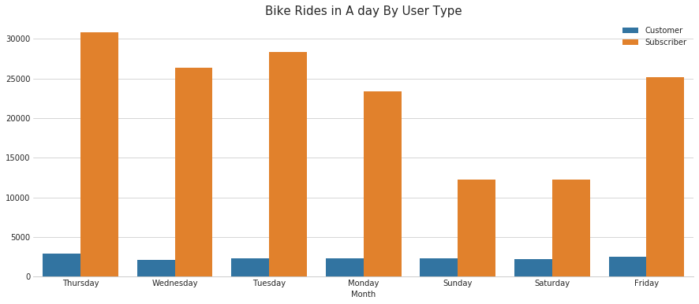

```python
plt.figure(figsize=(15,6))
plt.title('Bike Rides in A day By User Type', fontsize=15)
ax = sb.countplot(data=bike_data_clean, x='start_day', hue='user_type')

ax.set(xlabel='Month', ylabel='')

#Remove legend title
sb.despine(fig=None, ax=None, top=True, right=True, left=True, bottom=False, offset=None, trim=False)
plt.gca().legend().set_title('');
```

- A lot of Bike riders each day were subscribers

### Comparison of user_type during the day

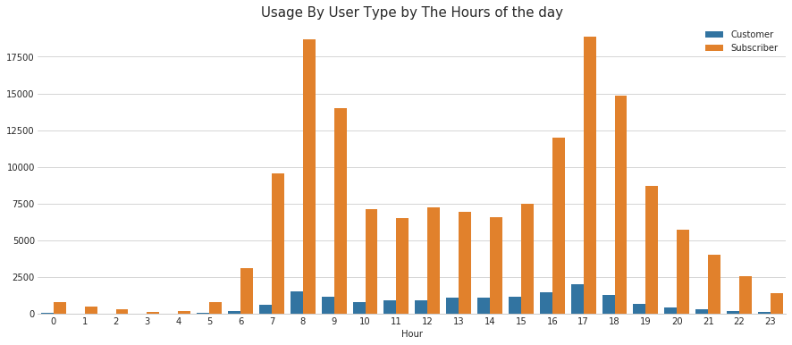

```python
plt.figure(figsize=(15,6))
plt.title('Usage By User Type by The Hours of the day', fontsize=15)
chart = sb.countplot(data=bike_data_clean, x='hour', hue='user_type')

chart.set(xlabel='Hour', ylabel='')

# Remove legend title
sb.despine(fig=None, ax=None, top=True, right=True, left=True, bottom=False, offset=None, trim=False)
plt.gca().legend().set_title('');
```

### Of the features you investigated, were there any unusual distributions? Did you perform any operations on the data to tidy, adjust, or change the form of the data? If so, why did you do this?

- I had to add a column for the users age group, grouped into young, middle aged and senior to be able to see what age group most bike riders lie in.

## Multivariate Exploration

### Average duration of bike rides in a week based on user type

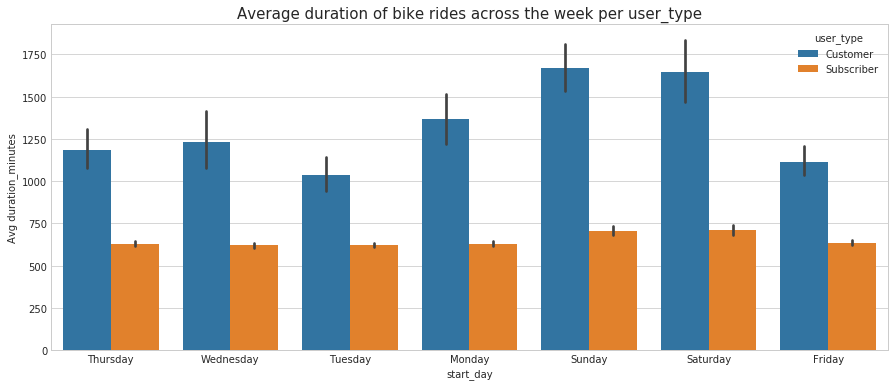

```python
plt.figure(figsize=(15,6))
sb.barplot(data=bike_data_clean, x='start_day', y='duration_sec', hue='user_type')
plt.ylabel('Avg duration_minutes')
plt.title('Average duration of bike rides across the week per user_type', size=15);
```

- subscibers generally have pretty much the same average bike minutes through out the week.
- on weekend the customers average bike ride is much higher

### Discuss the distribution(s) of your variable(s) of interest. Were there any unusual points? Did you need to perform any transformations?

- I looked at the average duration of bike trips taken throughout the week by the User Type

### Of the features you investigated, were there any unusual distributions? Did you perform any operations on the data to tidy, adjust, or change the form of the data? If so, why did you do this?

- subscibers generally have pretty much the same average bike riding time through out the week compared to customers

## Conclusions

Most trips were taken between Monday and Frday with the highest number of trips occuring on Thursdays and Tuesdays, the weekend has fewer number of trips taken.

The rush hours; going to work in the morning (8 and 9 hrs) and closing in the evening (17 and 18 hrs) have the highest trip records

About 90% of the trips were taken by subscribers

Most of the trips were taken by males (>70%)

Customers spend more duration than subscribers

Customer type doesn't really affect the number of trips per weekday

Customers travel for longer durations regardless of the day of the week as compared to subscribers.

```python
# save data
bike_data_clean.to_csv('bike_clean.csv', index=False)
```